# SRM Chapter 5.2

theBudgetActuary

# Classification Trees

Last section we covered regression trees where we would build a tree with a numeric output. This section we will build trees in a similar manner but now with the goal of predicting a categorical output.

## Predictions with Classification Trees

Predictions with classification trees are made the exact same way as with regression trees.

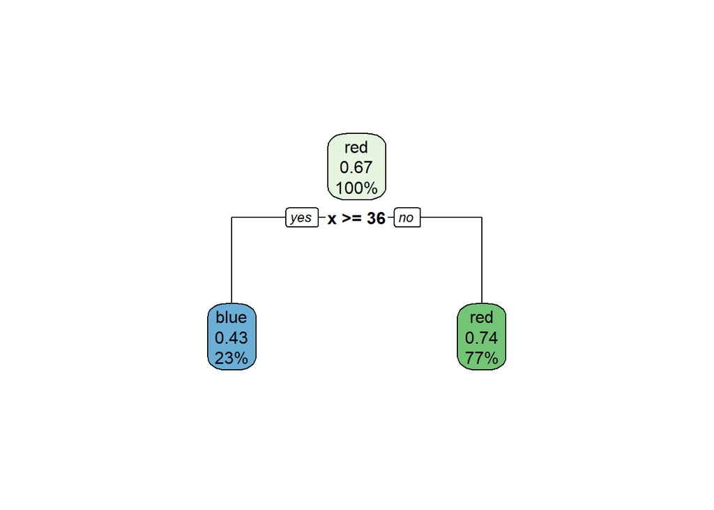

From the plot above if our predictor value of x $\ge$ 36 then we predict blue, else we predict red.

## Creating Splits

Since our output is a binary variable we can no longer use SSE to decide model fit. Instead, we have three options in order to choose our splits:

1. **Error Rate:**

$E=1-\underset{k}{max} (\hat{p}_{mk})$

$\hat{p}_{mk}$ - Number predicted correct / total in subgroup

With classification trees the leaf predicts the mode instead of the average like in regression trees. Error rate is simply the fraction of the observations in a subgroup that are of the minority class. If 50 observations in a leaf are ‘yes’ while 10 are ‘no’ the leaf will predict yes. The error rate would then be 10/60=.167. Can take any value between 0 and .5.

2. **Gini Index:**

$G=\sum_{k=1}^{K} \hat{p}_{mk}(1-\hat{p}_{mk})$

or

$G=1-\sum_{k=1}^{K} (p_{i})^{2}$

3. **Entropy**

$D=-\sum_{k=1}^{K} \hat{p}_{mk} log\ \hat{p}_{mk}$

Another measure of purity that takes small values when there is predominately one class in a leaf, and larger values when the number of values in each class of a leaf are near equal. If 50 observations are ‘yes’ and 10 are ‘no’ in a leaf, the entropy would be: $-(\frac{50}{60}\ ln\frac{50}{60}+\frac{10}{60}\ ln\frac{10}{60})=.45$. Can take any value between 0 and .693.

For all three options choose the split that creates the smallest value. Generally the two purity measures of entropy and gini-index are used to grow the trees, while accuracy is used to prune the trees. (James et al.)

#### Sources:

James, G., Witten, D., Hastie, T., & Tibshirani, R. (n.d.). An introduction to statistical learning: With applications in R.